# What makes a country happy

### Introduction and Motivation

Every year the world happiness report is published. The report aims to measure the happiness of people living in the countries of earth as well as the factors that might influence that countries overall happiness. Better understanding what makes a countries happy could give insight into how world leaders could better and more effectively fulfill the needs of the general populace. It also could give an individual an indicator of what countries might be a good place to live or visit should they have that privilege. The following analysis aims to use the data science pipeline in order to identify what relationships exist (if any) between a countries reported happiness score and the countries internal and external factors. We take a look at the world happiness reports from 2015 to 2021 which are records of the data collected from 2014-2020.

#### Set Up

Below are the packages I will be using for my analysis most of these are standard python data science tools

```python
import pandas as pd
import numpy as np
import math
import seaborn as sns
import matplotlib.pyplot as plt
from sklearn import linear_model
from sklearn.model_selection import train_test_split
from sklearn import metrics as metrics
```

#### Data Loading

For our data we will be using the happiness reports that were published by the gallup world poll and retrieved from kaggle. Since our data was split into different years we will store each years data as a different dataframe

```python
dataframes = {}
years = [2015,2016,2017,2018,2019,2020,2021]
for year in years:
    dataframes[year] = pd.read_csv("happiness_reports/"+str(year)+".csv")
dataframes[2015].head()
```

|  | Country | Region | Happiness Rank | Happiness Score | Standard Error | Economy (GDP per Capita) | Family | Health (Life Expectancy) | Freedom | Trust (Government Corruption) | Generosity | Dystopia Residual |
| --- | --- | --- | --- | --- | --- | --- | --- | --- | --- | --- | --- | --- |
| 0 | Switzerland | Western Europe | 1 | 7.587 | 0.03411 | 1.39651 | 1.34951 | 0.94143 | 0.66557 | 0.41978 | 0.29678 | 2.51738 |
| 1 | Iceland | Western Europe | 2 | 7.561 | 0.04884 | 1.30232 | 1.40223 | 0.94784 | 0.62877 | 0.14145 | 0.43630 | 2.70201 |
| 2 | Denmark | Western Europe | 3 | 7.527 | 0.03328 | 1.32548 | 1.36058 | 0.87464 | 0.64938 | 0.48357 | 0.34139 | 2.49204 |
| 3 | Norway | Western Europe | 4 | 7.522 | 0.03880 | 1.45900 | 1.33095 | 0.88521 | 0.66973 | 0.36503 | 0.34699 | 2.46531 |
| 4 | Canada | North America | 5 | 7.427 | 0.03553 | 1.32629 | 1.32261 | 0.90563 | 0.63297 | 0.32957 | 0.45811 | 2.45176 |

#### Tidy Data

There are a couple issues with the data the way it's been presented to us.

To begin the data is split across seven years. Since were looking for generalized relationships across time were gonna need to combine these tables. Combining the tables will make assessing information easier and more readily available. However we will need to account for time in our analysis later on. So we can record the year as a separate column.

Secondly some years have more Categories than others in order to have a standardized analysis we will only be looking at categories that span all years. More specifically we will be looking at the reported **Happiness Score, GDP per Capita, Social Support, Life Expectancy, Freedom, Trust in Government, and Generosity**

```python
dataframes[2015]
```

|  | Country | Region | Happiness Rank | Happiness Score | Standard Error | Economy (GDP per Capita) | Family | Health (Life Expectancy) | Freedom | Trust (Government Corruption) | Generosity | Dystopia Residual |
| --- | --- | --- | --- | --- | --- | --- | --- | --- | --- | --- | --- | --- |
| 0 | Switzerland | Western Europe | 1 | 7.587 | 0.03411 | 1.39651 | 1.34951 | 0.94143 | 0.66557 | 0.41978 | 0.29678 | 2.51738 |
| 1 | Iceland | Western Europe | 2 | 7.561 | 0.04884 | 1.30232 | 1.40223 | 0.94784 | 0.62877 | 0.14145 | 0.43630 | 2.70201 |
| 2 | Denmark | Western Europe | 3 | 7.527 | 0.03328 | 1.32548 | 1.36058 | 0.87464 | 0.64938 | 0.48357 | 0.34139 | 2.49204 |
| 3 | Norway | Western Europe | 4 | 7.522 | 0.03880 | 1.45900 | 1.33095 | 0.88521 | 0.66973 | 0.36503 | 0.34699 | 2.46531 |
| 4 | Canada | North America | 5 | 7.427 | 0.03553 | 1.32629 | 1.32261 | 0.90563 | 0.63297 | 0.32957 | 0.45811 | 2.45176 |
| ... | ... | ... | ... | ... | ... | ... | ... | ... | ... | ... | ... | ... |
| 153 | Rwanda | Sub-Saharan Africa | 154 | 3.465 | 0.03464 | 0.22208 | 0.77370 | 0.42864 | 0.59201 | 0.55191 | 0.22628 | 0.67042 |
| 154 | Benin | Sub-Saharan Africa | 155 | 3.340 | 0.03656 | 0.28665 | 0.35386 | 0.31910 | 0.48450 | 0.08010 | 0.18260 | 1.63328 |
| 155 | Syria | Middle East and Northern Africa | 156 | 3.006 | 0.05015 | 0.66320 | 0.47489 | 0.72193 | 0.15684 | 0.18906 | 0.47179 | 0.32858 |
| 156 | Burundi | Sub-Saharan Africa | 157 | 2.905 | 0.08658 | 0.01530 | 0.41587 | 0.22396 | 0.11850 | 0.10062 | 0.19727 | 1.83302 |
| 157 | Togo | Sub-Saharan Africa | 158 | 2.839 | 0.06727 | 0.20868 | 0.13995 | 0.28443 | 0.36453 | 0.10731 | 0.16681 | 1.56726 |

158 rows × 12 columns

The code below creates dataframes for each years happiness data for countries puts it into a format that will be easy to use and then concatenates it into one large data frame making the year a new column

```python
# first we standardize each years data
columns = ["Country","Happiness Score", "GDP per Capita", "Social Support", "Life Expectancy", "Freedom" ,"Trust in Gov't","Generosity"]
arranged = ["Country","Happiness Score", "GDP per Capita", "Social Support", "Life Expectancy", "Freedom" ,"Generosity","Trust in Gov't"]
def std_2015():
    df = dataframes[2015]
    df = df.drop(columns=["Region","Happiness Rank", "Standard Error", "Dystopia Residual"])
    df.columns = columns
    df = df[arranged]
    df["Year"] = 2015
    return df

def std_2016():
    df = dataframes[2016]
    df = df.drop(columns = ["Region","Happiness Rank", "Lower Confidence Interval", "Upper Confidence Interval","Dystopia Residual"])
    df.columns = columns
    df = df[arranged]
    df["Year"] = 2016
    return df

def std_2017():
    df = dataframes[2017]
    df = df.drop(columns = ["Happiness.Rank","Whisker.high", "Whisker.low", "Dystopia.Residual"])
    df.columns = arranged
    df["Year"] = 2017
    return df

def std_2018():
    df = dataframes[2018]
    df = df.drop(columns = ["Overall rank"])
    df.columns = arranged
    df["Year"] = 2018
    return df

def std_2019():
    df = dataframes[2019]
    df = df.drop(columns = ["Overall rank"])
    df.columns = arranged
    df["Year"] = 2019
    return df

def std_2020():
    df = dataframes[2020]
    df = df.drop(columns = ["Regional indicator","Standard error of ladder score","upperwhisker","lowerwhisker",
                        "Logged GDP per capita", "Social support","Healthy life expectancy","Freedom to make life choices",
                        "Generosity", "Perceptions of corruption", "Ladder score in Dystopia", "Dystopia + residual"])
    df.columns = arranged
    df["Year"] = 2020
    return df

def std_2021():
    dataframes[2021]
    df = dataframes[2021]
    df = df.drop(columns = ["Regional indicator","Standard error of ladder score","upperwhisker","lowerwhisker",
                        "Logged GDP per capita", "Social support","Healthy life expectancy","Freedom to make life choices",
                        "Generosity", "Perceptions of corruption", "Ladder score in Dystopia", "Dystopia + residual"])
    df.columns = arranged
    df["Year"] = 2021
    return df
```

```python
#Merge Dataframes
clean_frames = [std_2015(),std_2016(),std_2017(),std_2018(),std_2019(),std_2020(),std_2021()]
final_frame = pd.concat(clean_frames,ignore_index=True)
```

#### Missing data

Since we want to make the final data frame standard across years I've decided to use the 2020's dataset way of labeling the regions. Unfortunately there were a couple countries/territories that weren't a part of the 2020 data so I had to find their regions and fill them out manually.

There was only one row with completely missing data in a column this was the United Arab Emirates Trust in Gov't column. I can only speculate why this particular column was missing. This one row shouldnt significantly affect the rest of the data. Thus I've decided to replace the null value with the mean Trust in Gov't from the region in that year

```python
#Add regions
arranged = ["Country","Region","Year","Happiness Score", "GDP per Capita", "Social Support", "Life Expectancy", "Freedom" ,"Generosity","Trust in Gov't"]
missing_regions = {'Oman': "Middle East and North Africa",
                   'Qatar': "Middle East and North Africa",
                   'Taiwan': "East Asia",
                   'Suriname': "Latin America and Caribbean",
                   'Hong Kong': "East Asia",
                   'Bhutan': "South Asia",
                   'Somaliland region': "Sub-Saharan Africa",
                   'Sudan': "Sub-Saharan Africa",
                   'Djibouti': "Sub-Saharan Africa",
                   'Angola': "Sub-Saharan Africa",
                   'Syria': "Middle East and North Africa",
                   'Puerto Rico': "Latin America and Caribbean",
                   'Belize': "Latin America and Caribbean",
                   'Somalia': "Sub-Saharan Africa",
                   'Somaliland Region': "Sub-Saharan Africa",
                   'Hong Kong S.A.R., China': "East Asia",
                   'Trinidad & Tobago': "Latin America and Caribbean",
                   'Northern Cyprus': "Western Europe",
                   'North Macedonia': "Central and Eastern Europe"}
def get_region(country):
    frame = dataframes[2020].loc[dataframes[2020]["Country name"]==country]
    if frame.size > 0:
        return frame["Regional indicator"].values[0]
    else:
        return missing_regions[country]

regions = final_frame.apply(lambda row: get_region(row["Country"]), axis = 1)
final_frame["Region"] = regions
final_frame = final_frame[arranged]
final_frame = final_frame.rename(columns={"Country":"Country/Territory"})
final_frame
```

|  | Country/Territory | Region | Year | Happiness Score | GDP per Capita | Social Support | Life Expectancy | Freedom | Generosity | Trust in Gov't |
| --- | --- | --- | --- | --- | --- | --- | --- | --- | --- | --- |
| 0 | Switzerland | Western Europe | 2015 | 7.587 | 1.39651 | 1.34951 | 0.94143 | 0.66557 | 0.29678 | 0.41978 |
| 1 | Iceland | Western Europe | 2015 | 7.561 | 1.30232 | 1.40223 | 0.94784 | 0.62877 | 0.43630 | 0.14145 |
| 2 | Denmark | Western Europe | 2015 | 7.527 | 1.32548 | 1.36058 | 0.87464 | 0.64938 | 0.34139 | 0.48357 |
| 3 | Norway | Western Europe | 2015 | 7.522 | 1.45900 | 1.33095 | 0.88521 | 0.66973 | 0.34699 | 0.36503 |
| 4 | Canada | North America and ANZ | 2015 | 7.427 | 1.32629 | 1.32261 | 0.90563 | 0.63297 | 0.45811 | 0.32957 |
| ... | ... | ... | ... | ... | ... | ... | ... | ... | ... | ... |
| 1079 | Lesotho | Sub-Saharan Africa | 2021 | 3.512 | 0.45100 | 0.73100 | 0.00700 | 0.40500 | 0.10300 | 0.01500 |
| 1080 | Botswana | Sub-Saharan Africa | 2021 | 3.467 | 1.09900 | 0.72400 | 0.34000 | 0.53900 | 0.02700 | 0.08800 |
| 1081 | Rwanda | Sub-Saharan Africa | 2021 | 3.415 | 0.36400 | 0.20200 | 0.40700 | 0.62700 | 0.22700 | 0.49300 |
| 1082 | Zimbabwe | Sub-Saharan Africa | 2021 | 3.145 | 0.45700 | 0.64900 | 0.24300 | 0.35900 | 0.15700 | 0.07500 |
| 1083 | Afghanistan | South Asia | 2021 | 2.523 | 0.37000 | 0.00000 | 0.12600 | 0.00000 | 0.12200 | 0.01000 |

1084 rows × 10 columns

```python
final_frame[final_frame.isnull().any(axis=1)]
```

|  | Country/Territory | Region | Year | Happiness Score | GDP per Capita | Social Support | Life Expectancy | Freedom | Generosity | Trust in Gov't |
| --- | --- | --- | --- | --- | --- | --- | --- | --- | --- | --- |
| 489 | United Arab Emirates | Middle East and North Africa | 2018 | 6.774 | 2.096 | 0.776 | 0.67 | 0.284 | 0.186 | NaN |

```python
mean_trust = final_frame.loc[(final_frame["Region"]=="Middle East and North Africa") & (final_frame["Year"]==2018),"Trust in Gov't"].mean()
final_frame.at[489,"Trust in Gov't"]= mean_trust
```

#### Summary of Columns

Now that our data has been tidied up I offer a brief summary of each columns meaning and what the data for each column represents

**Country/Territory** This is the country or territory the data for this particular row was collected in.

**Region** This is the region the country is geographically or culturally a part of.

**Year** This is the year the data for this particular row was collected on.

**Happiness Score** This represents the mean happiness of the residents of a particular country. It ranges from 0 to 10 with 0 being the least happy and 10 being the most happy.

**GDP per Capita**GDP per capita is a country's economic output divided by its population.

**Social Support**Represents how well residents feel supported by friends, family members and social programs

**Life Expectancy**Reports a countries life expectancy on a given year on a standardized scale

**Freedom**Reports residents satisfaction in their ability to make choices that impact their lives

**Generosity**Reports how likely residents were to donate to charity

**Trust in Gov't**Reports residents perception of corruption in their respective governments

#### Exploratory Data Analysis

Now that our data has been tidied up. It's time to perform some exporatory analysis and visualization of the data. In this section we'll try to find relationships between the columns. Our ultimate goal is to see what relationships or correlations exist with the Happiness Score of a country. In other words if the appropriate relationships exist can we use some subset of the columns in order to predict the happiness score.

We begin by plotting happiness scores against column values in order to see if we can observe any relationships

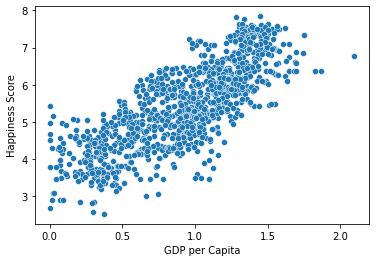

```python
sns.scatterplot(data=final_frame, y = "Happiness Score", x = "GDP per Capita")
```

There seems to be a strong positive linear relationship between a countries gdp and its happiness score. Generally speaking weatlhier countries seem to be happier. This is not all that surprising a result and is the relationship I expected to occur.

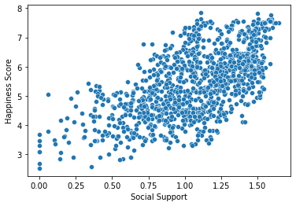

```python
sns.scatterplot(data=final_frame, y = "Happiness Score", x = "Social Support")
```

There also seems to be positive linear relationship between a countries Social Support rating and its happiness score. Generally speaking a country/territories residents fell happier when they feel supported by family and friends

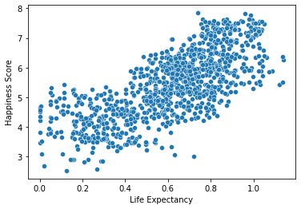

```python
sns.scatterplot(data=final_frame, y = "Happiness Score", x = "Life Expectancy")
```

There seems to be positive linear relationship between a countries/territories life expectancy rating and its happiness score. Generally speaking a country/territories residents fell happier when they live longer

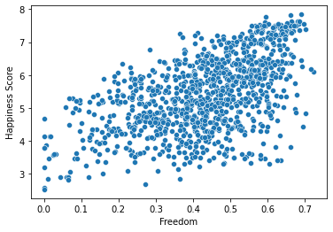

```python
sns.scatterplot(data=final_frame, y = "Happiness Score", x = "Freedom")
```

There seems to be positive linear relationship between a countries/territories freedom rating and its happiness score. Generally speaking a country/territories residents fell happier when they feel as though they have a choice in how their lives are going.

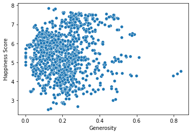

```python
sns.scatterplot(data=final_frame, y = "Happiness Score", x = "Generosity")
```

Interestingly generosity does not seem to have a relationship with a populations happiness scores. In fact most countries generosity fit within the 0.0 to the 0.4 range. Perhaps this indicates that generosity is fixed within a certain range or perhaps there is another variable that influences generosity

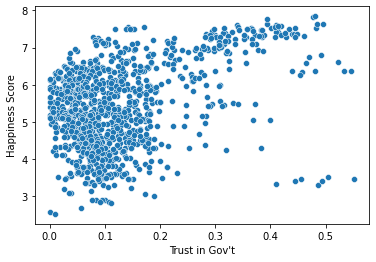

```python
sns.scatterplot(data=final_frame, y = "Happiness Score", x = "Trust in Gov't")
```

Similar to generosity Trust in Gov't also doesn't seem to influence a countries happiness score that much. While happiest countries\territories seem to trust their governments. For the rest of the world it doesn't seem to matter as much in influencing the Happiness Score.

```
<function matplotlib.pyplot.show(close=None, block=None)>
```

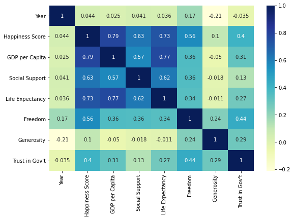

```python
plt.figure(figsize=(9,6))
corr = final_frame.corr()
sns.heatmap(corr, annot=True, cmap="YlGnBu")
plt.show
```

As expected our correlation heat map shows that there is a correlation between the happiness score of a country and its GDP per capita, Social Support, Life Expectancy, and Freedom. What was interesting is that it also showed that there is also a positive correlation between a countries GDP per capita and its Social Support, and Life Expectancy. This also makes sense as people in wealthier countries can afford to support each other and might have access to better health care.

Even though there might be some correleation between GDP, Social Support, and Life Expectancy we are still going to treat them as independent when making our model for Happiness Score

The correlation doesn't necessarily imply causation moreover these factors individually might influence happiness score in a way that just using the gdp might not be able to.

#### Machine Learning

Now that we have established there is probably a linear relationship between the happiness score of a country and its GDP per capita, Social Support, Life Expectancy, and Freedom. It's time to train a model so that given, GDP per capita, Social Support, Life Expectancy, and Freedom for a hypothetical country we can predict the happiness score for that country.

We will be using a sklearns linear regression module in order to form a multiple regression model for our data

The first thing we need to do is to split our data into training and testing subsets and the code below will perform this task

```python
train, test = train_test_split(final_frame, test_size=0.2)
```

After splitting our data we create a linear model using our training data and test it against our training data. Then we get some metrics in order to see how well our data performed in predicting happiness scores given our inputs

```python
X_train = train[["GDP per Capita", "Social Support", "Life Expectancy", "Freedom"]]
X_test = test[["GDP per Capita", "Social Support", "Life Expectancy", "Freedom"]]
y_train = train["Happiness Score"]
y_test = test["Happiness Score"]
regr = linear_model.LinearRegression()
regr.fit(X_train, y_train)

#predictions using our model
y_train_pred = regr.predict(X_train)
y_test_pred = regr.predict(X_test)

#This gives us some metrics on how well our model did
def regression_results(y_true, y_pred):
    # Regression metrics
    explained_variance=metrics.explained_variance_score(y_true, y_pred)
    mean_absolute_error=metrics.mean_absolute_error(y_true, y_pred)
    mse=metrics.mean_squared_error(y_true, y_pred)
    mean_squared_log_error=metrics.mean_squared_log_error(y_true, y_pred)
    median_absolute_error=metrics.median_absolute_error(y_true, y_pred)
    r2=metrics.r2_score(y_true, y_pred)
    print('explained_variance: ', round(explained_variance,4))
    print('mean_squared_log_error: ', round(mean_squared_log_error,4))
    print('r2: ', round(r2,4))
    print('MAE: ', round(mean_absolute_error,4))
    print('MSE: ', round(mse,4))
    print('RMSE: ', round(np.sqrt(mse),4))
    print("")

regression_results(y_train, y_train_pred)
regression_results(y_test, y_test_pred)
```

```
explained_variance:  0.7489
mean_squared_log_error:  0.0088
r2:  0.7489
MAE:  0.4424
MSE:  0.3187
RMSE:  0.5646

explained_variance:  0.735
mean_squared_log_error:  0.0086
r2:  0.7318
MAE:  0.4502
MSE:  0.3126
RMSE:  0.5591
```

#### Analysis of results

So we created our model and predicted values based on our training set and our test set. Then I ran some metrics in order to see how well our model did in predicting values. The two most important metrics above are the explained_variance score, and the r2 score. In both scores a 1.0 is the best and the model is progressively worse the lower it goes

Explained variation measures the proportion to which a mathematical model accounts for the variation (dispersion) of a given data set.

r2 score, is the proportion of the variance in the dependent variable that is predictable from the independent variable(s).

In both scores our model perfomed at approximately .75 which I believe is acceptable in showing that our model is accurate in predicting the happiness score of a country given the "GDP per Capita", "Social Support", "Life Expectancy", and "Freedom" scores of a country

```
0.7489439028220823
0.7318268275924483
```

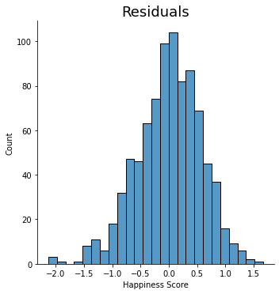

```python
sns.displot(y_train - y_train_pred)
plt.title("Residuals", size=18)
print(regr.score(X_train,y_train))
print(regr.score(X_test, y_test))
```

### Final Thoughts

Human beings are complicated and trying to predict human behavior or predict human fulfillment is very difficult to do. We are influenced by many different things which can affect our mood and behavior in a variety of ways. So this tutorial isn't claiming to have found a way to predict general human happiness. However in the introduction I stated that a goal of this tutorial and the subsequent analysis that followed was to identify what relationships exist between a countries happiness score and its internal and external factors.

In our exploratory stage after plotting our data we were able to observe a positive linear relationship between Happiness Score and GDP per Capita, Happiness Score and Social Support, Happiness Score and Life Expectancy, and Happiness Score and Freedom.

Using our observations as a guide we were able to formulate a model that was able to accurately predict the overall happiness score of a country given "GDP per Capita", "Social Support", "Life Expectancy", and "Freedom".

### Resources

More information on world happiness data can be found at [world happiness](https://worldhappiness.report/)

Datasets I used [link](https://www.kaggle.com/mathurinache/world-happiness-report)

##### Statistical Analysis

[Correlation Matrix](https://pandas.pydata.org/docs/reference/api/pandas.DataFrame.corr.html)

##### Machine Learning

[Linear Regression](https://ml-cheatsheet.readthedocs.io/en/latest/linear_regression.html#:~:text=Linear%20Regression%20is%20a%20supervised,Simple%20regression)

[R2-score and Explained_Variance](https://scikit-learn.org/stable/modules/model_evaluation.html#r2-score)